# The $n_i > 50$ residual-normality bypass: scope, evidence, and boundary

Working note for the visStatistics Discussion section

2026-06-01

# 1 The justification of the $n>50$ gate

The bypass **fires before** the homoscedasticity (Levene) gate and before the two-vs-more-groups split. At the moment it decides, it does **not** yet know which of four mean-based tests will run. Its justification therefore cannot rest on a single source — it must cover a 2×2 of branches.

Here is an overview of the literature regarding threshold values in the four branches:

|  | $k = 2$ | $k > 2$ |
| --- | --- | --- |
| **equal variance** (Student / Fisher) | Blanca et al. (2017) — Student is the two-group special case | Blanca et al. (2017) |
| **unequal variance** (Welch-$t$ / Welch-ANOVA) | Fagerland (2012) | Delacre et al. (2019) |

- **Blanca et al. (2017)** — Fisher one-way ANOVA: Type I error within Bradley’s bounds across skewness up to 2, kurtosis up to 6, group sizes 5–100, *equal variances*.
- **Fagerland (2012)** — Welch’s $t$, unequal variances, two groups: $n \approx 50$ holds the 5% rate across a wide skewness range; only heavy skew needs $\approx 200$.
- **Delacre et al. (2019)** — Welch’s one-way ANOVA, unequal variances, $k > 2$: $\approx 50$ per group suffices, except for $k > 4$ under pronounced skew, where $\approx 100$ per group is needed. *(page to re-verify before manuscript use.)*

# 2 An honest test case: equal means, different medians

To probe the bypass, build $k = 5$ lognormal groups with **equal population means** but **unequal variance and skew**. For a lognormal, $\text{mean} = e^{\mu + \sigma^2/2}$, so fixing $\mu_i = M - \sigma_i^2/2$ holds every group mean at $e^{M}$ while spread and skew rise with $\sigma_i$. Side effect: medians $= e^{\mu_i}$ **differ**.

Under equal means, **every rejection by a mean-based test is a false positive** — it cannot be faked by a built-in mean difference.

```r
sdlog   <- c(A = 0.3, B = 0.5, C = 0.7, D = 0.9, E = 1.1)  # rising spread/skew
M       <- 1                                               # every group mean = exp(M)
meanlog <- M - sdlog^2 / 2                                 # equalise the means

data.frame(
  group           = names(sdlog),
  pop_mean        = round(exp(meanlog + sdlog^2/2), 3),    # all equal
  pop_median      = round(exp(meanlog), 3),                # differ
  pop_sd_rank     = rank(sdlog)
)
```

```
##   group pop_mean pop_median pop_sd_rank
## A     A    2.718      2.599           1
## B     B    2.718      2.399           2
## C     C    2.718      2.128           3
## D     D    2.718      1.813           4
## E     E    2.718      1.484           5
```

```r
make_data <- function(n) {
  grp <- factor(rep(names(n), times = n))
  val <- unlist(lapply(names(n), function(k) rlnorm(n[k], meanlog[k], sdlog[k])))
  list(grp = grp, val = val)
}

# pull the test visstat() actually ran (method + p) from its result object
visstat_test <- function(res) {
  for (el in res)
    if (is.list(el) && !is.null(el$method) && !is.null(el$p.value))
      return(list(method = trimws(el$method), p = el$p.value))
  list(method = "(not found)", p = NA_real_)
}
```

# 3 What visstat() does, across three size regimes

Each regime keeps the same structure; only the group sizes change. The plots are the default `visstat()` panels. The printed block contrasts the test `visstat()` chose with Kruskal–Wallis.

```r
welch_case <- function(n, label) {
  set.seed(1)
  d   <- make_data(n)
  res <- visstat(d$grp, d$val)
  vt  <- visstat_test(res)
  kw  <- kruskal.test(d$val ~ d$grp)
  cat("===========", label, "===========\n")
  cat("means  :", paste(round(tapply(d$val, d$grp, mean),   2), collapse = " / "), "\n")
  cat("medians:", paste(round(tapply(d$val, d$grp, median), 2), collapse = " / "), "\n")
  cat(sprintf("visstat()  %-48s p = %.4g\n", vt$method, vt$p))
  cat(sprintf("Kruskal    %-48s p = %.4g\n\n", kw$method, kw$p.value))
}

welch_case(c(A = 55,  B = 65,  C = 75,  D = 85,  E = 95),  "n in (50,100)")
welch_case(c(A = 110, B = 130, C = 150, D = 170, E = 190), "n > 100")
welch_case(c(A = 510, B = 530, C = 550, D = 570, E = 590), "n > 500")
```

```
## =========== n in (50,100) ===========
## means  : 2.76 / 2.84 / 2.62 / 2.8 / 2.57
## medians: 2.75 / 2.43 / 1.9 / 1.79 / 1.49
## visstat()  One-way analysis of means (not assuming equal variances) p = 0.9097
## Kruskal    Kruskal-Wallis rank sum test                     p = 9.738e-05
##
## =========== n > 100 ===========
## means  : 2.8 / 2.64 / 2.73 / 2.95 / 2.64
## medians: 2.72 / 2.21 / 2.19 / 1.72 / 1.22
## visstat()  One-way analysis of means (not assuming equal variances) p = 0.7949
## Kruskal    Kruskal-Wallis rank sum test                     p = 2.338e-11
##
## =========== n > 500 ===========
## means  : 2.74 / 2.68 / 2.76 / 2.78 / 2.66
## medians: 2.57 / 2.36 / 2.08 / 1.67 / 1.5
## visstat()  One-way analysis of means (not assuming equal variances) p = 0.8875
## Kruskal    Kruskal-Wallis rank sum test                     p = 1.387e-35
```

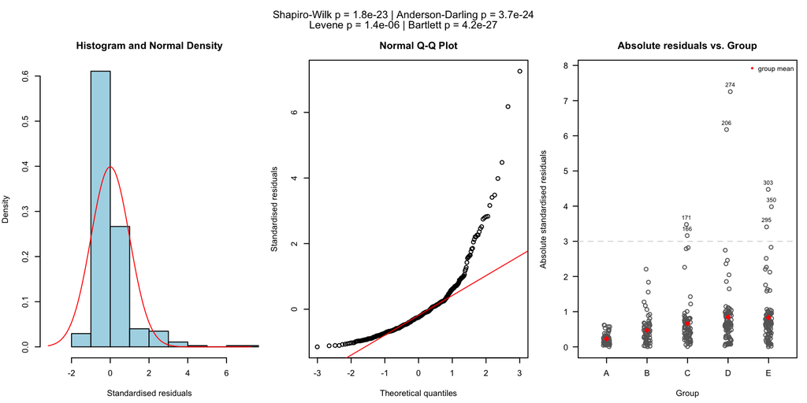

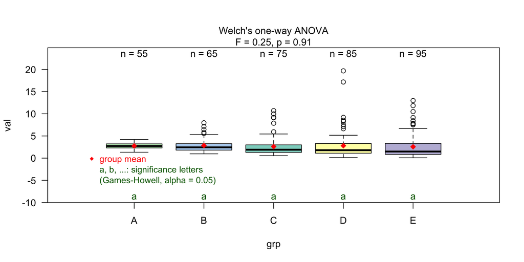

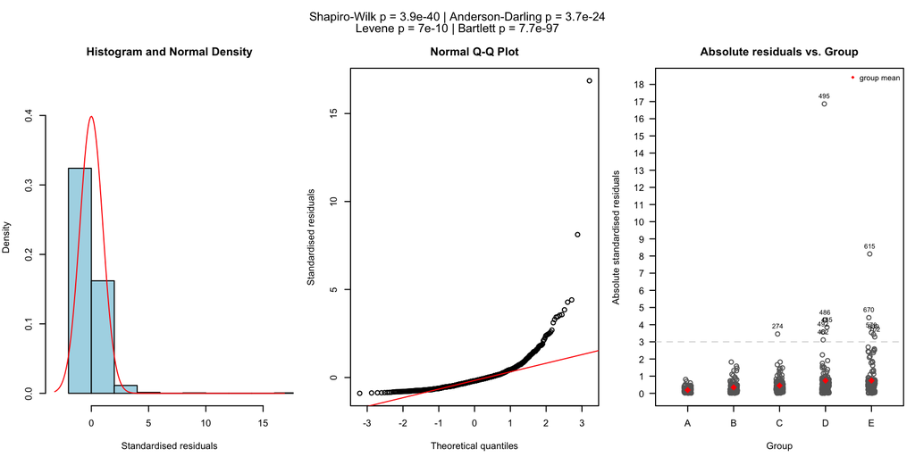

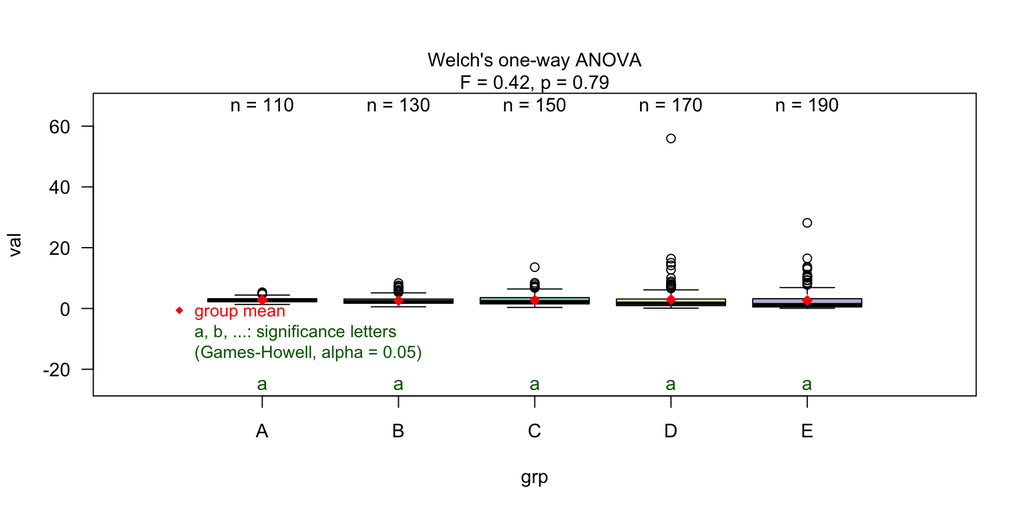

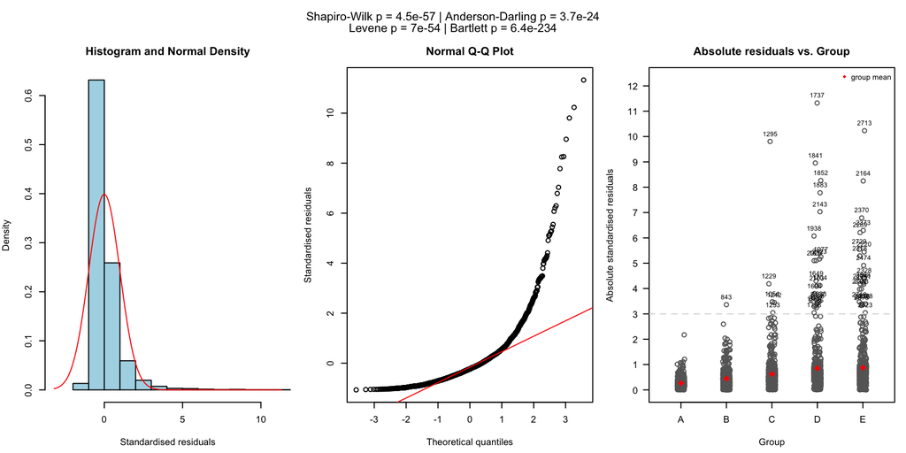

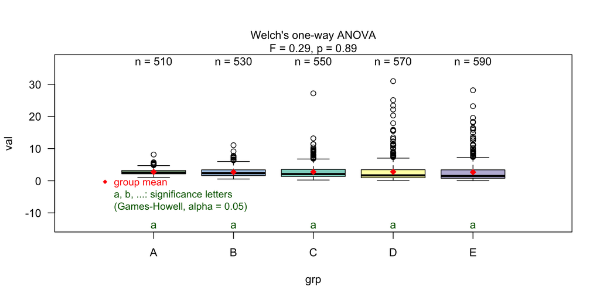

**Reading it:** means are equal, so `visstat()` (Welch’s ANOVA) correctly does *not* reject. Medians differ, so Kruskal–Wallis correctly does. The divergence is a property of the question each test asks (mean vs. rank/location), not a bug — and it is untouched by sample size.

# 4 Does raising the threshold to 100 fix anything?

```r
welch_typeI <- function(n, nrep = 2000, alpha = 0.05) {
  grp <- factor(rep(names(n), times = n))
  set.seed(1)
  mean(replicate(nrep, {
    val <- unlist(lapply(names(n), function(k) rlnorm(n[k], meanlog[k], sdlog[k])))
    oneway.test(val ~ grp, var.equal = FALSE)$p.value < alpha
  }))
}

data.frame(
  regime       = c("n in (50,100)", "n > 100", "n > 500"),
  welch_typeI  = c(
    welch_typeI(c(A = 55,  B = 65,  C = 75,  D = 85,  E = 95)),
    welch_typeI(c(A = 110, B = 130, C = 150, D = 170, E = 190)),
    welch_typeI(c(A = 510, B = 530, C = 550, D = 570, E = 590))
  )
)
```

```
##          regime welch_typeI
## 1 n in (50,100)      0.0885
## 2       n > 100      0.0775
## 3       n > 500      0.0575
```

For this $k = 5$ skewed, heteroscedastic corner: the false-positive rate is inflated at $n \in (50,100)$, only **borderline** at $n > 100$ (sitting on Bradley’s ceiling), and comfortably controlled only well past 100 per group. So a blanket “raise the cutoff to 100” does **not** cleanly fix it — matching Delacre et al. (2019). A single group-size threshold cannot cover the $k > 4$ skewed-heteroscedastic corner.

# 5 Consequence for the package

- Keep the bypass and the cutoff at 50: clearly supported for the cases the package targets (the 2×2 above).
- Do **not** chase the corner with a $k$-dependent threshold: it cannot be made clean, and the bypass deliberately favours not switching to rank-based tests over negligible large-sample deviations.
- Instead, rely on the package’s existing safeguards: every test is reported with an **effect size**, and the **residual diagnostics are displayed**, so a significant mean-based result paired with a small effect size stays visible.

# 6 Proposed Discussion paragraph (replaces current L898)

> It also depends on which test the routing will reach. Holding the false-positive rate to its $\alpha = 5\%$ target, simulation evidence supports the threshold of 50 across all of these branches. For equal variances—Fisher’s one-way ANOVA, with Student’s t-test as its two-group special case—a Monte Carlo study kept the Type I error within Bradley’s bounds in every condition examined: skewness up to 2, kurtosis up to 6, and group sizes from 5 to 100 [@Blanca:2017]. For unequal variances with two groups—Welch’s t-test—group sizes near 50 hold the 5% rate across a wide range of skewness, and only heavily skewed distributions call for substantially larger samples, on the order of 200 [@Fagerland:2012]. For unequal variances with more than two groups—Welch’s one-way ANOVA—about 50 observations per group suffice, except when more than four groups are compared under pronounced skew, where roughly 100 per group are required [@Delacre:2019].

**Before manuscript use:** (1) re-verify the Delacre page for the “$\approx 100$ for $k > 4$” claim; (2) ensure `@Blanca:2017` is in `REFERENCES.bib` (author-managed).